# O mesmo modelo em tidymodels

Lasso e floresta aleatória para a oferta de ônibus da SPTrans

Autor

Lab 2: Prática Avançada em Data Science e Visualização, PADS Insper

**NotaDocumento irmão**

Este arquivo tem um par idêntico em Python, `sklearn.qmd`. Mesma pergunta, mesmos dados, mesmos dois modelos, mesma sequência de seções. A ideia é abrir os dois lado a lado e ler a mesma etapa nas duas linguagens.

Os números não batem na casa decimal entre os dois documentos: os geradores de números aleatórios de R e Python são diferentes, então a divisão treino e teste não é exatamente a mesma. A ordem de grandeza e a conclusão são.

## A pergunta e os dados

Queremos prever o **headway**: o intervalo programado entre dois ônibus da mesma linha, em segundos. Cada registro é uma combinação de linha, sentido e faixa horária, montada a partir do GTFS da SPTrans cruzado com a API Olho Vivo.

```r
library(tidymodels)
library(readr)
library(dplyr)

set.seed(42)
tidymodels_prefer()
```

```r
dados <- read_csv("dados/viagens.csv.gz", show_col_types = FALSE)

numericas <- c(
  "hora_inicio", "n_paradas", "extensao_km", "duracao_min",
  "velocidade_kmh", "paradas_por_km", "dist_centro_origem_km",
  "dist_centro_destino_km", "n_linhas_origem", "n_linhas_destino",
  "pct_paradas_corredor"
)
categoricas <- c(
  "periodo_dia", "tipo_dia", "sentido", "area_operacao",
  "tipo_linha", "corredor_principal"
)

dados <- dados |>
  select(route_id, headway_seg, all_of(numericas), all_of(categoricas)) |>
  mutate(across(all_of(categoricas), as.factor))

glue::glue(
  "{format(nrow(dados), big.mark = '.')} registros | ",
  "{n_distinct(dados$route_id)} linhas de ônibus"
)
```

```
37.357 registros | 1142 linhas de ônibus
```

```r
mean(is.na(dados$corredor_principal))
```

```
[1] 0.7095324
```

Repare no `as.factor`: em R basta declarar que a coluna é categórica e o resto do ecossistema entende. Em Python, o `OneHotEncoder` recusa uma coluna que misture `int` e `str`, e é preciso converter na mão depois de ler o CSV.

**ImportanteO `select()` acima não é arrumação, é proteção**

A tabela original tem 33 colunas, e três delas são identificadores de texto: `trip_id`, `route_short_name` e `route_long_name`. Se elas sobreviverem até a receita, o `recipe(headway_seg ~ .)` vai tratá-las como preditoras e criar milhares de dummies a partir de colunas que são praticamente únicas por linha.

O sintoma aparece no `tune_grid`:

```
warning: There are new levels in `route_short_name`: "1012-10", "1016-10", ...
```

Se você vir esse aviso, o `select()` desta seção não rodou na sua sessão. Rode o documento do início. Aviso sobre nível novo em `tipo_linha` é normal e esperado (há linhas de trem e metrô raras); sobre `trip_id`, nunca é.

## Divisão treino e teste, por grupo

Cada linha de ônibus aparece cerca de 30 vezes, uma por faixa horária. Se a mesma linha cair nos dois lados, o modelo decora a linha em vez de aprender o padrão de oferta. Por isso a divisão é **por grupo**.

```r
divisao <- group_initial_split(dados, group = route_id, prop = 0.75)
treino <- training(divisao)
teste <- testing(divisao)

dobras <- group_vfold_cv(treino, group = route_id, v = 5)

glue::glue(
  "treino: {nrow(treino)} registros de {n_distinct(treino$route_id)} linhas\n",
  "teste:  {nrow(teste)} registros de {n_distinct(teste$route_id)} linhas"
)
```

```
treino: 28006 registros de 857 linhas
teste:  9351 registros de 285 linhas
```

Uma diferença de forma: aqui o `group_initial_split()` devolve **um objeto** de onde saem treino e teste; o `GroupShuffleSplit` do Python devolve índices, e é você quem fatia. E o `route_id` viaja **dentro** do `data.frame`, enquanto em Python o vetor `groups` viaja por fora e precisa ser passado em toda chamada.

## A receita

```r
receita <- recipe(headway_seg ~ ., data = treino) |>
  update_role(route_id, new_role = "id") |>
  step_impute_median(all_numeric_predictors()) |>
  step_normalize(all_numeric_predictors()) |>
  step_novel(all_nominal_predictors()) |>
  step_unknown(all_nominal_predictors()) |>
  step_other(all_nominal_predictors(), threshold = 0.005) |>
  step_dummy(all_nominal_predictors()) |>
  step_zv(all_predictors())

receita
```

```
── Recipe ──────────────────────────────────────────────────────────────────────
```

```
── Inputs
```

```
Number of variables by role
```

```
outcome:    1
predictor: 17
id:         1
```

```
── Operations
```

```
• Median imputation for: all_numeric_predictors()
```

```
• Centering and scaling for: all_numeric_predictors()
```

```
• Novel factor level assignment for: all_nominal_predictors()
```

```
• Unknown factor level assignment for: all_nominal_predictors()
```

```
• Collapsing factor levels for: all_nominal_predictors()
```

```
• Dummy variables from: all_nominal_predictors()
```

```
• Zero variance filter on: all_predictors()
```

Quatro decisões que valem para os dois modelos:

- **mediana** para o que falta nas numéricas, porque resiste a valor extremo;
- **padronizar**, porque o lasso penaliza coeficiente e sem escala comum ele castiga quem tem unidade grande. A floresta não precisa disso, mas não se incomoda;
- **categoria explícita** para o que falta nas categóricas (`step_unknown`), em vez de descartar a linha. Ficar sem corredor é informação;
- **agrupar categoria rara** (`step_other`) e aceitar categoria nova (`step_novel`), porque em produção aparece linha que não existia.

**DicaDuas diferenças escondidas na receita**

Esta receita termina com **44 colunas** e a do Python, com o mesmo dado, termina com **62**. Duas causas somadas:

**`step_dummy()` cria k menos 1 colunas**, deixando um nível como referência, que é o que uma regressão espera. O `OneHotEncoder` do Python cria as k, a menos que você peça `drop="first"`. Isso explica **6** colunas, uma por variável categórica.

| variável | níveis | Python (`min_frequency=20`) | R (`step_other` + `step_dummy`) |
| --- | --- | --- | --- |
| `periodo_dia` | 5 | 5 | 4 |
| `tipo_dia` | 4 | 4 | 3 |
| `sentido` | 2 | 2 | 1 |
| `area_operacao` | 12 | 12 | 11 |
| `tipo_linha` | 20 | 20 | **7** |
| `corredor_principal` | 8 | 8 | 7 |
| **colunas categóricas** |  | **51** | **33** |
| mais 11 numéricas |  | **62** | **44** |

Quase toda a diferença está em `tipo_linha`, que tem 20 níveis: 13 deles não chegam a 139 registros e viram um `other` só. Nenhum dos dois comportamentos está errado; o errado seria não saber que a receita juntou treze categorias numa.

**DicaOrdem importa**

`step_normalize()` vem **antes** de `step_dummy()`. Se viesse depois, `all_numeric_predictors()` pegaria também as dummies recém-criadas e padronizaria colunas de zero e um. Em Python o problema não existe, porque cada caminho do `ColumnTransformer` recebe a sua própria lista de colunas.

`step_novel()` vem **antes** de `step_unknown()`. O `step_novel()` reserva um nível para categoria que só aparece depois do treino; o `step_unknown()` cuida do que está faltando. Na ordem trocada, o `recipes` avisa e converte o nível novo em `NA`, que já passou do ponto de ser tratado. O ecossistema do R avisa; vale ler o aviso.

O `update_role()` também não tem equivalente direto: ele diz que `route_id` está no `data.frame` mas não é preditor. Em Python isso se resolve simplesmente não colocando a coluna em `X`.

```r
espiada <- receita |> prep() |> bake(new_data = NULL)
glue::glue("{ncol(espiada) - 2} colunas depois do pré-processamento")
```

```
44 colunas depois do pré-processamento
```

```r
names(espiada)[1:12]
```

```
 [1] "route_id"               "hora_inicio"            "n_paradas"
 [4] "extensao_km"            "duracao_min"            "velocidade_kmh"
 [7] "paradas_por_km"         "dist_centro_origem_km"  "dist_centro_destino_km"
[10] "n_linhas_origem"        "n_linhas_destino"       "pct_paradas_corredor"
```

**Aviso**

Esse `prep()` acima é só para **olhar** o resultado. Ele não é usado no ajuste: quem vai chamar `prep()` na receita é o `workflow()`, dentro de cada dobra da validação cruzada. Rodar a receita na base inteira antes de dividir é o vazamento mais comum que existe.

## Modelo 1: lasso

```r
especificacao_lasso <- linear_reg(penalty = tune(), mixture = 1) |>
  set_engine("glmnet") |>
  set_mode("regression")

fluxo_lasso <- workflow() |>
  add_recipe(receita) |>
  add_model(especificacao_lasso)

grade_lasso <- tibble(penalty = c(0.1, 1, 10, 100))

resultado_lasso <- tune_grid(
  fluxo_lasso,
  resamples = dobras,
  grid = grade_lasso,
  metrics = metric_set(mae, rmse, rsq_trad)
)

melhor_lasso <- select_best(resultado_lasso, metric = "mae")
melhor_lasso
```

```
# A tibble: 1 × 2
  penalty .config
    <dbl> <chr>
1       1 pre0_mod2_post0
```

```r
collect_metrics(resultado_lasso) |>
  filter(.metric == "mae") |>
  select(penalty, mean, std_err)
```

```
# A tibble: 4 × 3
  penalty  mean std_err
    <dbl> <dbl>   <dbl>
1     0.1  592.    10.7
2     1    592.    10.6
3    10    594.    10.1
4   100    640.    12.4
```

O `mixture = 1` é o que faz do `linear_reg()` um lasso: mistura pura de L1. Com `mixture = 0` seria ridge, e entre 0 e 1, elastic net. Em Python são três classes diferentes (`Lasso`, `Ridge`, `ElasticNet`).

O lasso zera coeficiente, então ele também seleciona variável:

```r
lasso_final <- fluxo_lasso |>
  finalize_workflow(melhor_lasso) |>
  fit(data = treino)

coeficientes <- lasso_final |>
  extract_fit_parsnip() |>
  tidy() |>
  filter(term != "(Intercept)") |>
  mutate(tamanho = abs(estimate)) |>
  arrange(desc(tamanho))
glue::glue(
  "{sum(coeficientes$estimate == 0)} de {nrow(coeficientes)} ",
  "coeficientes foram zerados pelo lasso"
)
```

```
2 de 44 coeficientes foram zerados pelo lasso
```

```r
coeficientes |> select(term, estimate) |> head(10)
```

```
# A tibble: 10 × 2
   term                   estimate
   <chr>                     <dbl>
 1 periodo_dia_madrugada      933.
 2 area_operacao_M           -932.
 3 tipo_dia_util_e_sabado     737.
 4 periodo_dia_noite          493.
 5 area_operacao_X8           462.
 6 tipo_linha_X41             391.
 7 tipo_dia_other            -388.
 8 area_operacao_N            355.
 9 n_paradas                  343.
10 area_operacao_X6           332.
```

## Modelo 2: floresta aleatória

```r
especificacao_floresta <- rand_forest(trees = 200, min_n = tune()) |>
  set_engine("ranger", seed = 42) |>
  set_mode("regression")

fluxo_floresta <- workflow() |>
  add_recipe(receita) |>
  add_model(especificacao_floresta)

resultado_floresta <- tune_grid(
  fluxo_floresta,
  resamples = dobras,
  grid = tibble(min_n = c(5, 20)),
  metrics = metric_set(mae, rmse, rsq_trad)
)

melhor_floresta <- select_best(resultado_floresta, metric = "mae")
melhor_floresta
```

```
# A tibble: 1 × 2
  min_n .config
  <dbl> <chr>
1     5 pre0_mod1_post0
```

```r
floresta_final <- fluxo_floresta |>
  finalize_workflow(melhor_floresta) |>
  fit(data = treino)
```

Repare que **a receita é a mesma**. Trocar de modelo trocou o `add_model()` e a grade. É exatamente o que acontece do outro lado, trocando um passo do `Pipeline` e o dicionário do grid.

`min_n` no R é `min_samples_leaf` no Python, e `trees` é `n_estimators`. Os nomes dos hiperparâmetros são a parte mais chata da tradução: o `parsnip` padroniza os nomes entre motores, e o scikit-learn usa o nome de cada implementação.

## Comparação no teste

```r
metricas <- metric_set(mae, rmse, rsq_trad)

avaliar <- function(nome, ajustado) {
  bind_rows(
    treino |>
      mutate(.pred = predict(ajustado, treino)$.pred) |>
      metricas(truth = headway_seg, estimate = .pred) |>
      mutate(particao = "treino"),
    teste |>
      mutate(.pred = predict(ajustado, teste)$.pred) |>
      metricas(truth = headway_seg, estimate = .pred) |>
      mutate(particao = "teste")
  ) |>
    mutate(modelo = nome)
}

mediana_treino <- median(treino$headway_seg)

baseline <- bind_rows(
  treino |>
    mutate(.pred = mediana_treino) |>
    metricas(truth = headway_seg, estimate = .pred) |>
    mutate(particao = "treino"),
  teste |>
    mutate(.pred = mediana_treino) |>
    metricas(truth = headway_seg, estimate = .pred) |>
    mutate(particao = "teste")
) |>
  mutate(modelo = "baseline (mediana)")

resultados <- bind_rows(
  baseline,
  avaliar("lasso", lasso_final),
  avaliar("floresta", floresta_final)
) |>
  select(modelo, particao, .metric, .estimate) |>
  tidyr::pivot_wider(names_from = .metric, values_from = .estimate)

resultados |> mutate(across(where(is.numeric), \(x) round(x, 3)))
```

```
# A tibble: 6 × 5
  modelo             particao   mae  rmse rsq_trad
  <chr>              <chr>    <dbl> <dbl>    <dbl>
1 baseline (mediana) treino    682. 1033.   -0.221
2 baseline (mediana) teste     690. 1038.   -0.261
3 lasso              treino    576.  771.    0.319
4 lasso              teste     589.  787.    0.276
5 floresta           treino    293.  425.    0.794
6 floresta           teste     574.  766.    0.313
```

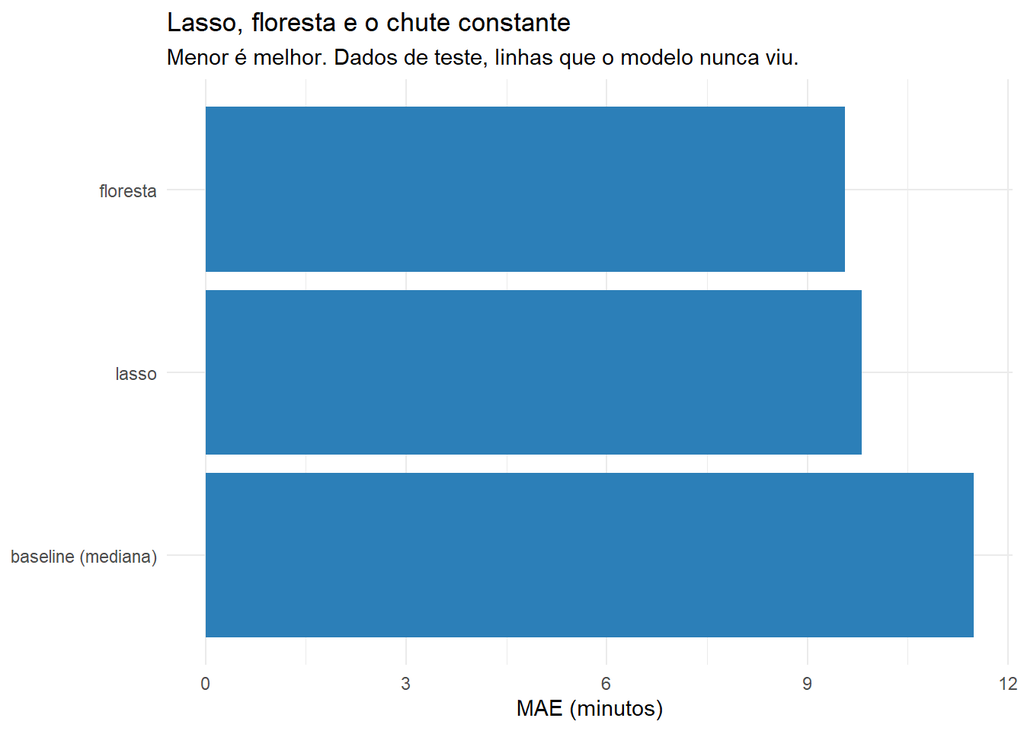

Figura 1: Erro médio absoluto no teste, em minutos.

```r
resultados |>
  filter(particao == "teste") |>
  ggplot(aes(x = reorder(modelo, -mae), y = mae / 60)) +
  geom_col(fill = "#2c7fb8") +
  coord_flip() +
  labs(
    title = "Lasso, floresta e o chute constante",
    subtitle = "Menor é melhor. Dados de teste, linhas que o modelo nunca viu.",
    x = NULL,
    y = "MAE (minutos)"
  ) +
  theme_minimal()
```

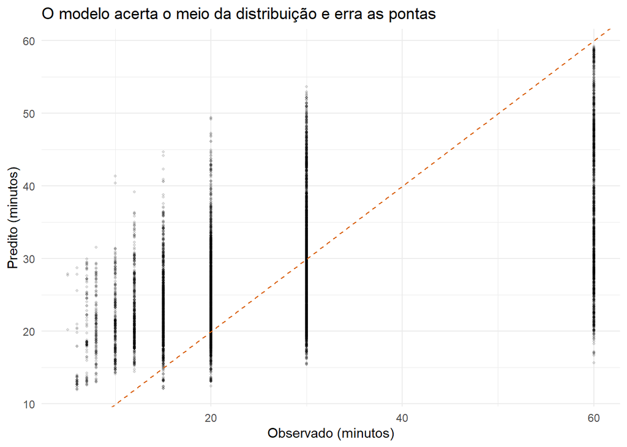

Figura 2: Observado contra predito, floresta aleatória, dados de teste.

```r
teste |>
  mutate(.pred = predict(floresta_final, teste)$.pred) |>
  ggplot(aes(x = headway_seg / 60, y = .pred / 60)) +
  geom_point(alpha = 0.12, size = 0.8) +
  geom_abline(intercept = 0, slope = 1, linetype = "dashed", color = "#d95f02") +
  labs(
    title = "O modelo acerta o meio da distribuição e erra as pontas",
    x = "Observado (minutos)",
    y = "Predito (minutos)"
  ) +
  theme_minimal()
```

## O que ler nessa tabela

1. **Os dois modelos ganham do baseline**, mas por pouco. O gargalo não é o algoritmo, são os dados: falta demanda, falta contrato de operação.
2. **A floresta ganha do lasso no teste**, e ganha muito mais no treino. Essa distância entre treino e teste é sobreajuste, e é o preço de um modelo flexível.
3. **O R² do baseline é negativo.** Não é bug: o R² compara com prever a *média*, e o baseline prevê a *mediana*, que é o chute constante certo sob MAE. Métrica e baseline precisam ser escolhidos juntos.

**Importante`rsq` e `rsq_trad` não são a mesma coisa**

Este documento usa `rsq_trad()`, não `rsq()`. O `yardstick::rsq()` é o **quadrado da correlação** entre observado e predito; com um baseline constante a correlação não existe e ele devolve `NA`. O `rsq_trad()` é o R² tradicional, `1 - SQE/SQT`, que é exatamente o que o `r2_score` do scikit-learn calcula, e que pode ficar negativo.

Se você comparar um relatório em R e um em Python e os R² não baterem, é aqui que costuma estar a diferença.

## Salvar o modelo

```r
library(bundle)

floresta_final |>
  bundle() |>
  saveRDS("modelo_floresta.rds")

modelo <- readRDS("modelo_floresta.rds") |> unbundle()
predict(modelo, head(teste))
```

[output not shown]

O `bundle()` existe porque muitos modelos de R guardam ponteiros para memória que não sobrevivem ao `saveRDS()` sozinho. Em Python, o `joblib.dump()` do `Pipeline` resolve o caso equivalente sem embrulho extra.

Se o objeto salvo **não** aceitar um `data.frame` cru, é sinal de que alguma transformação ficou fora do `workflow()`. Esse é o teste que separa um modelo que vai para produção de um que só funciona no notebook.